The dataset includes single-cell fluorescent measurements of Hoechst intensity in E.coli strain NCMM3722 (wild type). Data were personally collected and processed. Under the microscope, apparently there’a heterogeneity in Hoechst signals. The objective of this notebook is to classify this so-called “Phenotype” based solely on intensity. This cluster analysis will serve as an entry point to further investigate the kinetics of Hoechst accumulation and degradation. Firstly, a screening of clustering algorithms and number of clusters are performed. Then, clustering is performed with optimal algorithms and optimal number of clusters to classify the phenotypes. The results are then saved in a csv file. ## Load packages

```r
library(tidyverse)
```

```r
library(readxl)
library(plotly)
library(openxlsx)
library(gridExtra)
library(ggprism)
library(scales)
library(emojifont)
library(Cairo)
library(ggplot2)
library(ggnewscale)
library(stats)
library(sparklyr)
library(dplyr)
library(data.table)
library(clValid)
library(mclust)
library(tidymodels)
library(patchwork)
```

## Download data

```r
url <- "https://www.dropbox.com/s/ic053m6xixmag5t/HT_degradation_demo.csv?dl=1"
df_deg<- fread(url)
df_deg
```

```
##                                                                  IMAGE
##    1:               NMK1_no_H342_1p5%agarose_DAPI_1000ms_0m_1_w1PH.TIF
##    2:               NMK1_no_H342_1p5%agarose_DAPI_1000ms_0m_1_w1PH.TIF
##    3:               NMK1_no_H342_1p5%agarose_DAPI_1000ms_0m_1_w1PH.TIF
##    4:               NMK1_no_H342_1p5%agarose_DAPI_1000ms_0m_1_w1PH.TIF
##    5:               NMK1_no_H342_1p5%agarose_DAPI_1000ms_0m_1_w1PH.TIF
##   ---
## 3320: NMK1_15uM_H342_degradation_1p5%agarose_DAPI_100ms_90m_3_w1PH.TIF
## 3321: NMK1_15uM_H342_degradation_1p5%agarose_DAPI_100ms_90m_3_w1PH.TIF
## 3322: NMK1_15uM_H342_degradation_1p5%agarose_DAPI_100ms_90m_3_w1PH.TIF
## 3323: NMK1_15uM_H342_degradation_1p5%agarose_DAPI_100ms_90m_3_w1PH.TIF
## 3324: NMK1_15uM_H342_degradation_1p5%agarose_DAPI_100ms_90m_3_w1PH.TIF
##       INTENSITY INTENSITY.ch2.mean_c              LOCATION Time_m
##    1:  4102.696             30.87863  (x=672.46 y=1341.31)     -1
##    2:  4121.196             35.58952   (x=807.08 y=485.43)     -1
```

[output cut: 45 more lines]

## Cleaning up the dataframe. Remove unnecessary columns

```r
df1 <- subset( df_deg ,select = -c( IMAGE,
                                    INTENSITY,
                                    INTENSITY.ch2.mean_c,
                                    LOCATION,
                                    Final_OD600,
                                    Strain,
                                    Protocol,
                                    Date_and_growth_curve,
                                    Media,
                                    Exposure_time
                                    ))
# Remove time -1 (background measurements)
df2 <- df1[df1$Time_m != -1,]
df2
```

```
##       Time_m normed_intensity_ch2 HT_Conc_uM Genotype Phenotype Repeat
##    1:      0             30.27026        0.5       WT      dark      1
##    2:      0             38.10433        0.5       WT      dark      1
##    3:      0             38.81422        0.5       WT      dark      1
##    4:      0             46.90358        0.5       WT      dark      1
##    5:      0             41.01353        0.5       WT      dark      1
##   ---
## 3123:     90            129.51483       15.0       WT      dark      1
## 3124:     90            735.56150       15.0       WT      dark      1
## 3125:     90             75.55862       15.0       WT      dark      1
## 3126:     90            270.64246       15.0       WT      dark      1
## 3127:     90            122.30886       15.0       WT      dark      1
```

## Find optimal clustering algorithms with clValid package

```
## [1] "Currently working on HT concentration  0.5 uM"
##                  Score       Method Clusters
## Connectivity 2.9289683 hierarchical        2
## Dunn         2.0160283 hierarchical        2
## Silhouette   0.9395119 hierarchical        2
```

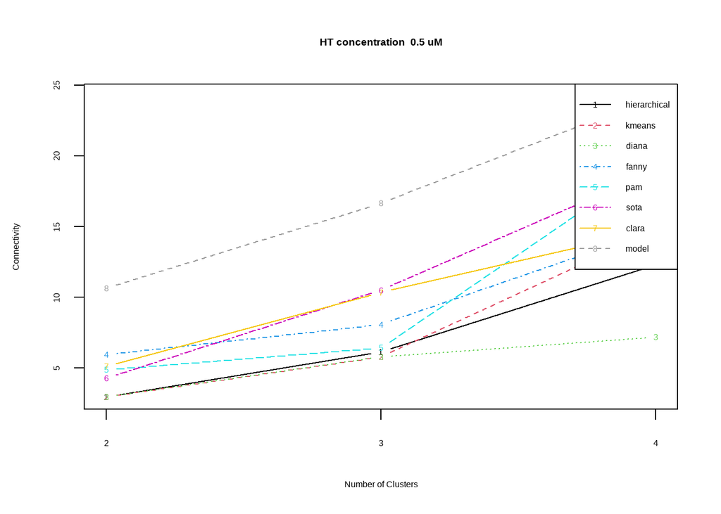

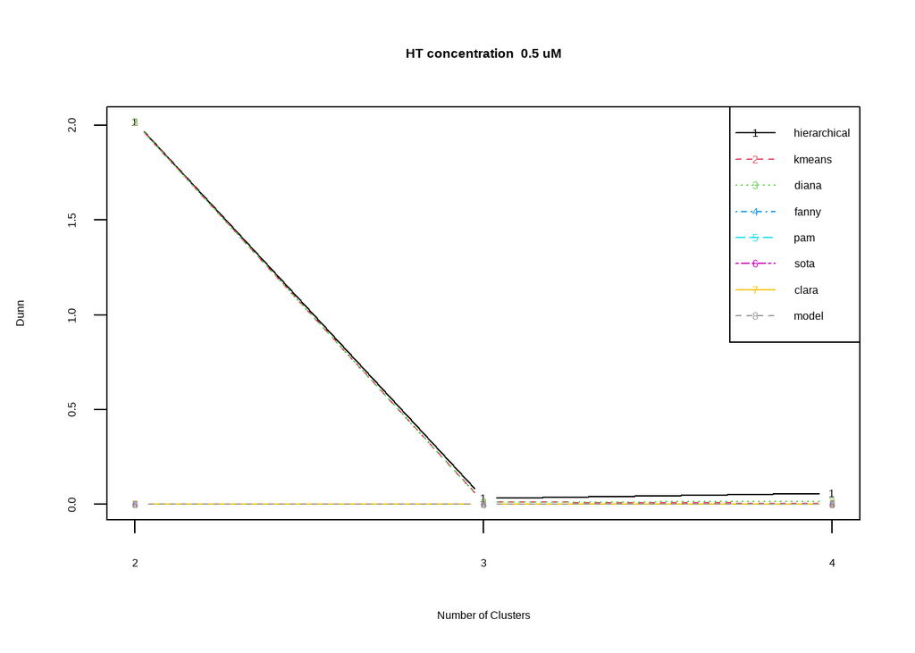

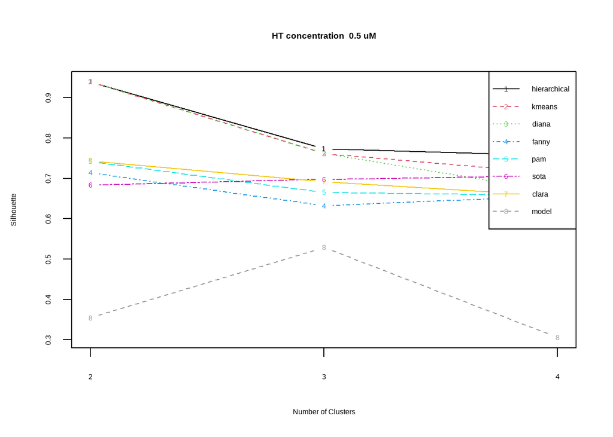

```
## [1] "Currently working on HT concentration  1 uM"
##                 Score       Method Clusters
## Connectivity 2.594841        model        2
## Dunn         3.521650 hierarchical        2
## Silhouette   0.958258 hierarchical        2
```

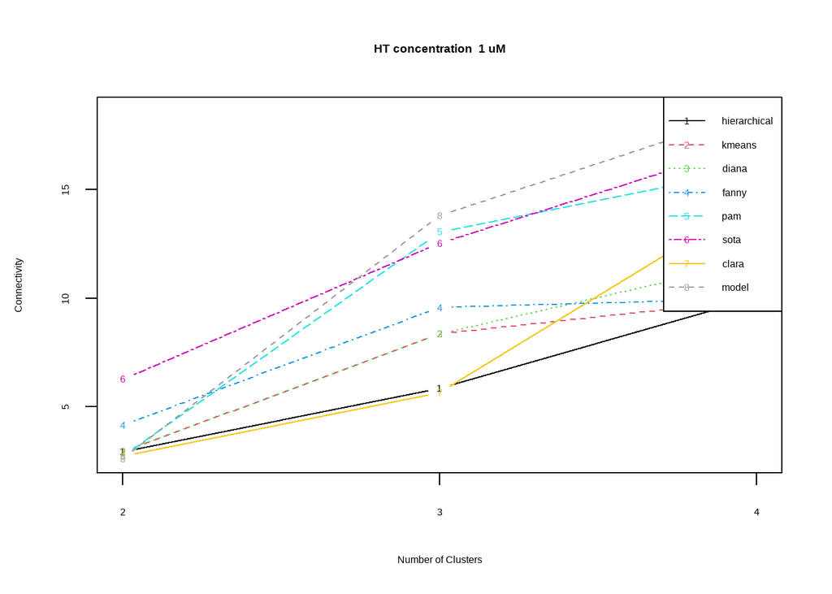

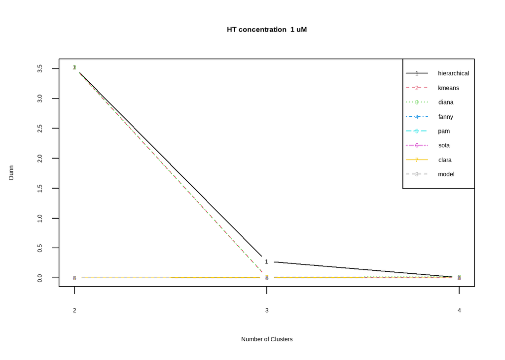

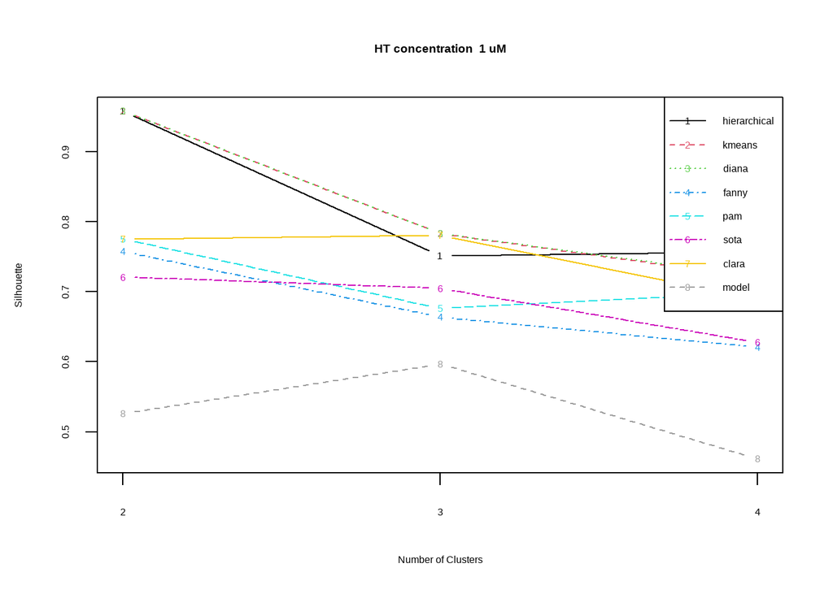

```
## [1] "Currently working on HT concentration  3 uM"
##                   Score       Method Clusters
## Connectivity 1.72619048        model        2
## Dunn         0.04529191 hierarchical        4
## Silhouette   0.86342021       kmeans        2
```

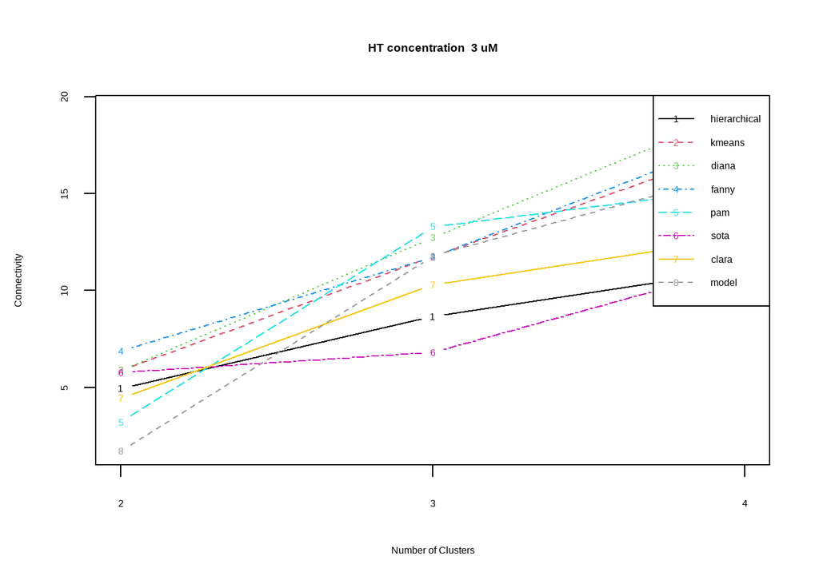

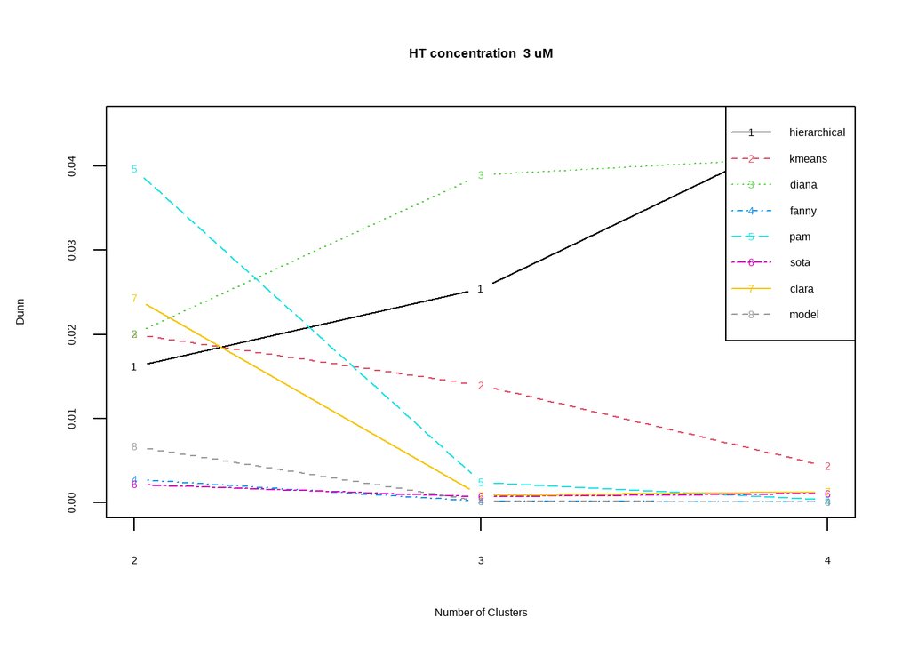

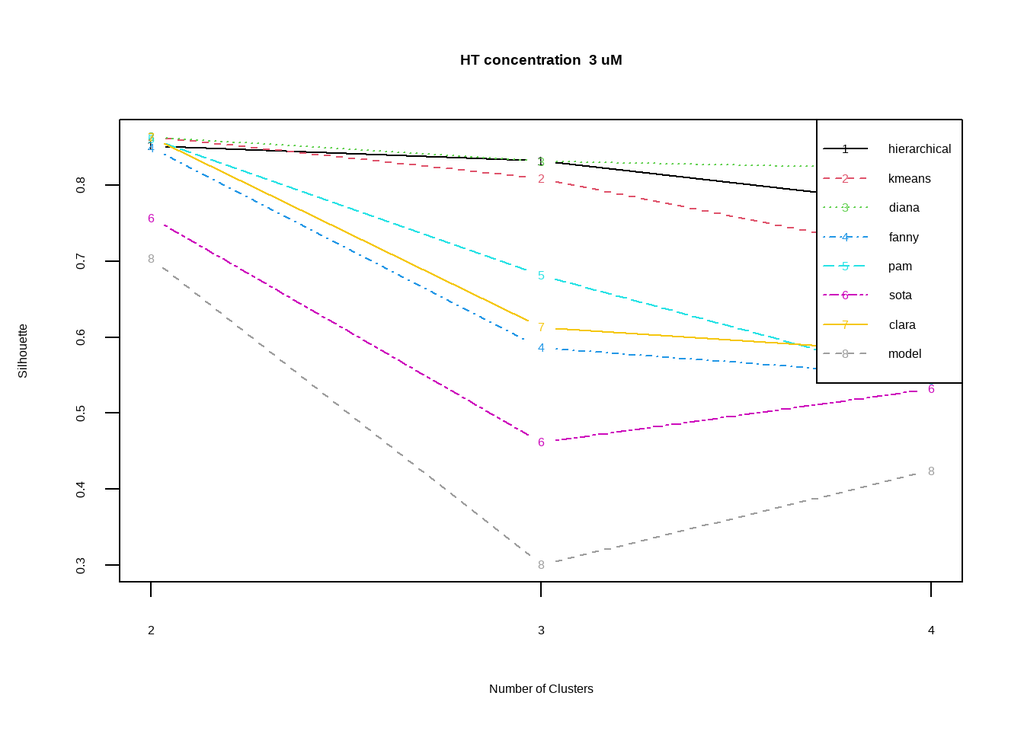

```
## [1] "Currently working on HT concentration  10 uM"
##                   Score       Method Clusters
## Connectivity 3.79126984 hierarchical        2
## Dunn         0.09974528 hierarchical        4
## Silhouette   0.78571161 hierarchical        2
```

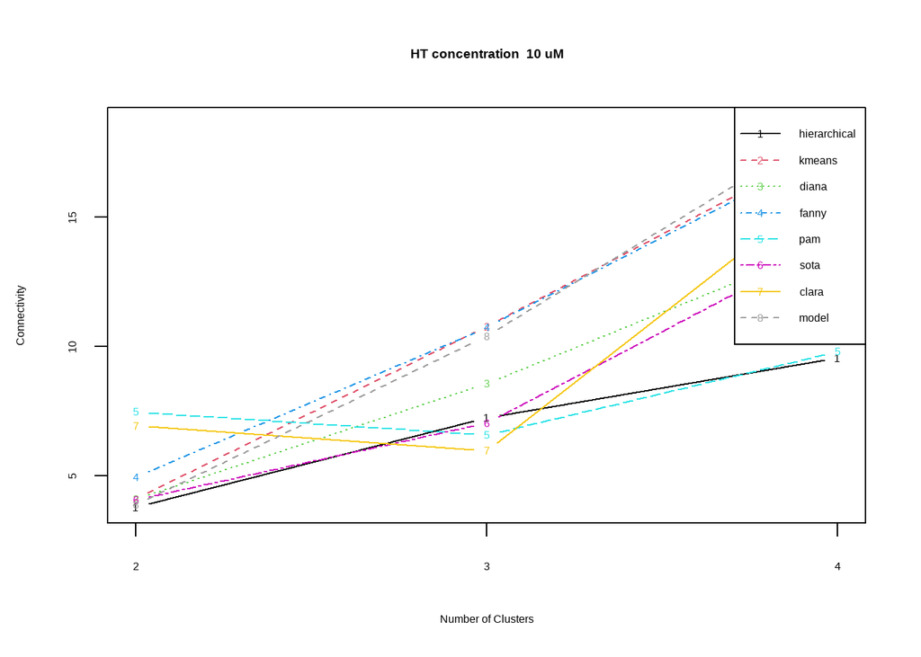

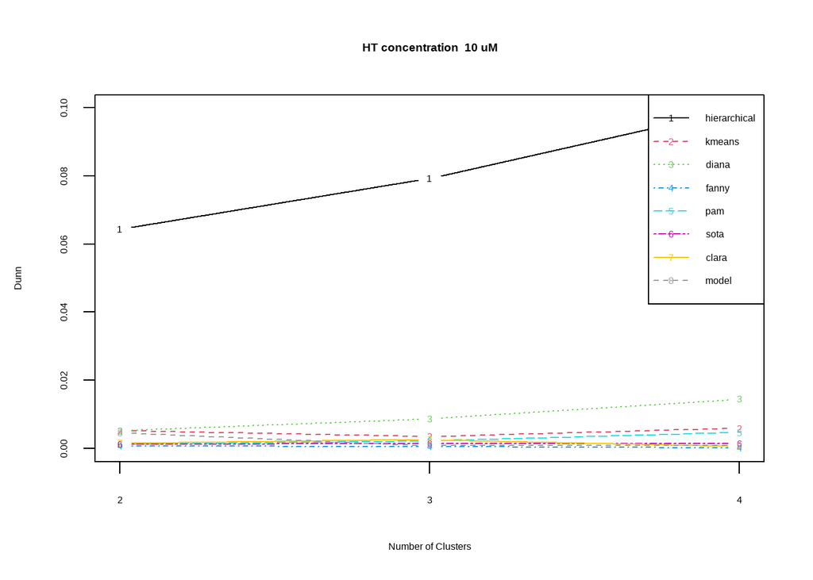

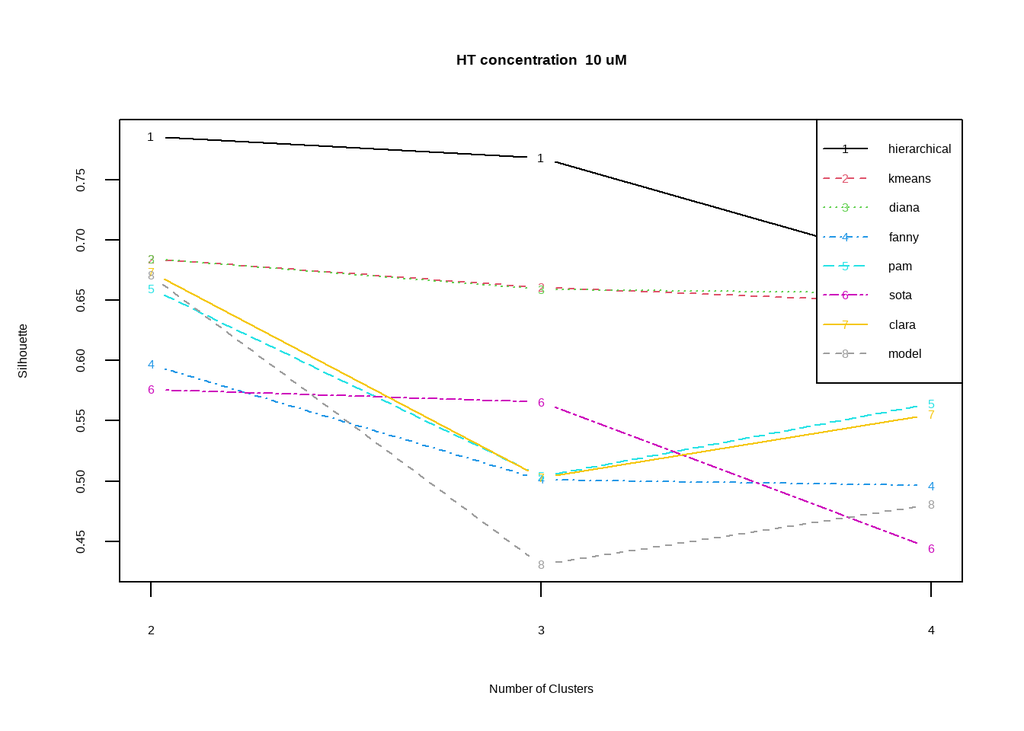

```
## [1] "Currently working on HT concentration  20 uM"
##                   Score       Method Clusters
## Connectivity 1.46904762 hierarchical        2
## Dunn         0.02773428 hierarchical        2
## Silhouette   0.56202482       kmeans        2
```

[6 more figures not shown]

```r
# normed_intensity_ch2 is fluorescent intensity after normalized with exposure time
# Choose algorithms need to be tested
clmethods <- c("hierarchical","kmeans", "diana", "fanny", "pam", "sota", "clara","model")
## Loop through all the concentrations to perform the tests
for (i in unique(df2$HT_Conc_uM)){
  data <- df2$normed_intensity_ch2[df2$HT_Conc_uM == i]
  pdf <- as.data.frame(as.numeric(data))
  val <- clValid(pdf, nClust = 2:4,clMethods = clmethods,
                 validation = "internal")

  print(paste("Currently working on HT concentration ",i,"uM"))
  print(optimalScores(val))
  plot(val,main = paste("HT concentration ",i,"uM"))
}
```

```r
# Create vectors to store the results of clustering
K_pred <- c()
H_pred <- c()
# Loop through all the concentrations
for (i in unique(df2$HT_Conc_uM)){
  # filter for data
  data <- df2$normed_intensity_ch2[df2$HT_Conc_uM == i]
  # perform k-means clustering on data and set results as kclust
  kclust <- data %>% kmeans(centers = 2)
  # append k-means results to K_pred vector
  K_pred <- append(K_pred, kclust$cluster)
  # calculate dissimilarity matrix from data then create hclust object on dissimilarity
  # matrix with method = "average"
  hclust <- data %>%
                dist()%>%
                    hclust(method = "average")
  # use cutree to cut hclust object into 2 clusters
  cut_avg <- cutree(hclust, k = 2)
  # append classification results to H_pred
  H_pred <- append(H_pred, cut_avg)

}
```

## Plot histogram of HT intensity distributions with predicted phenotype classification

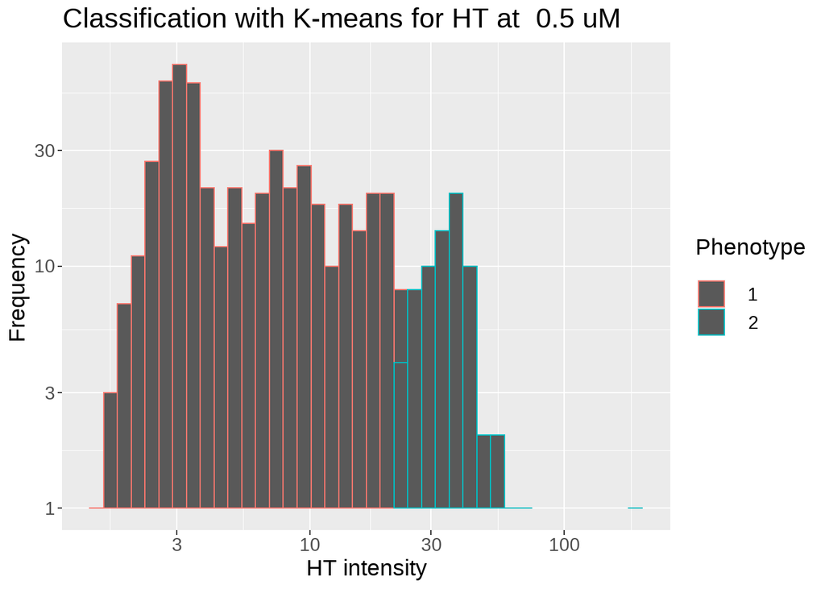

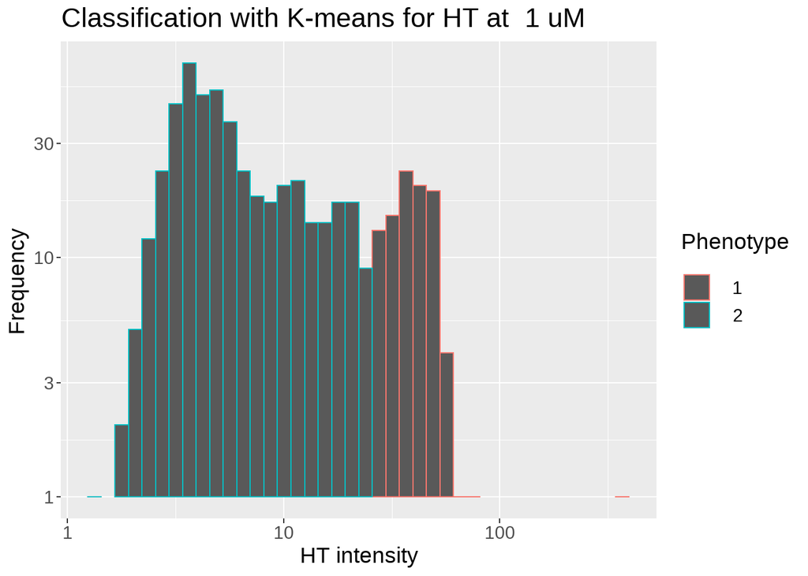

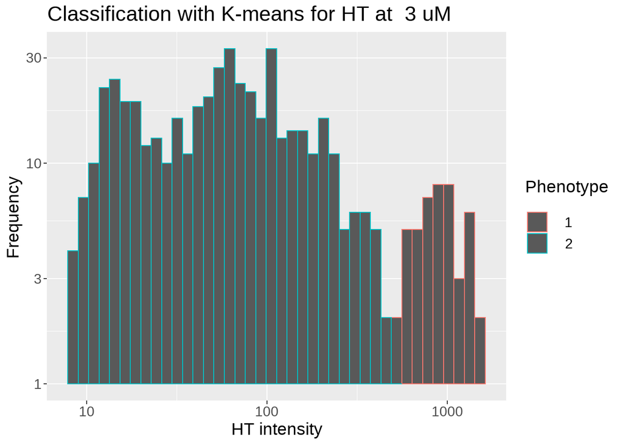

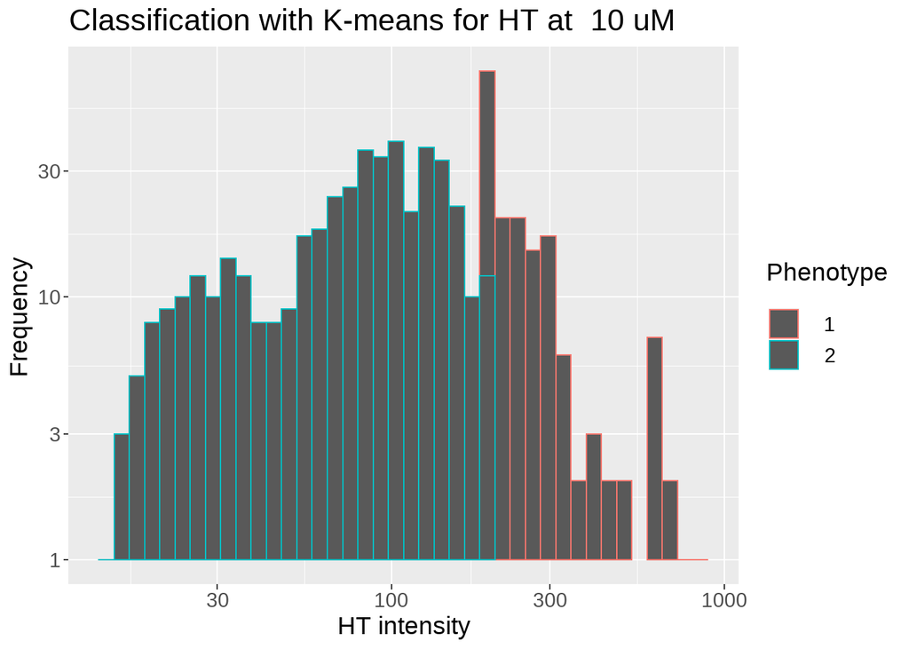

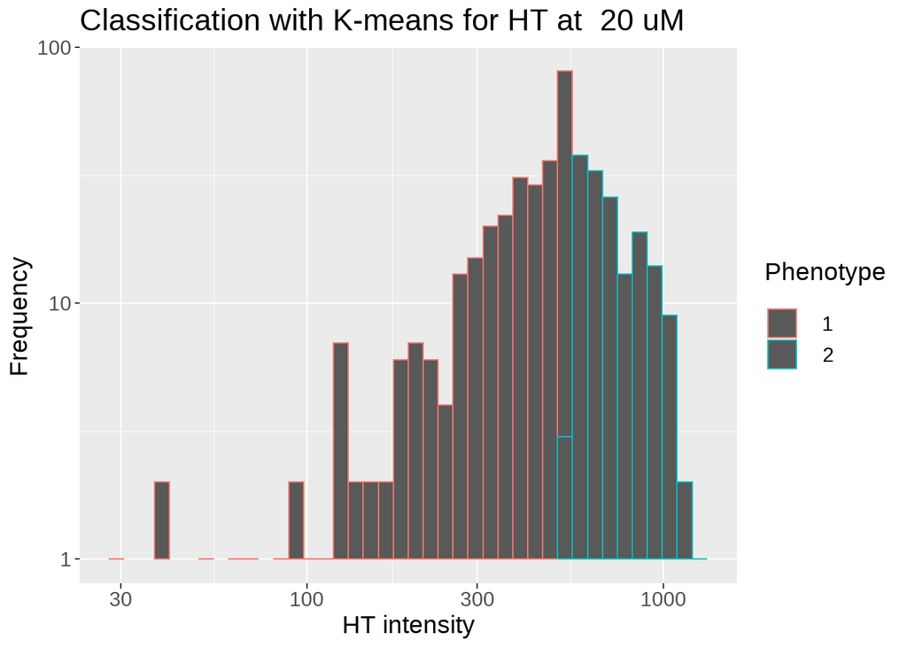

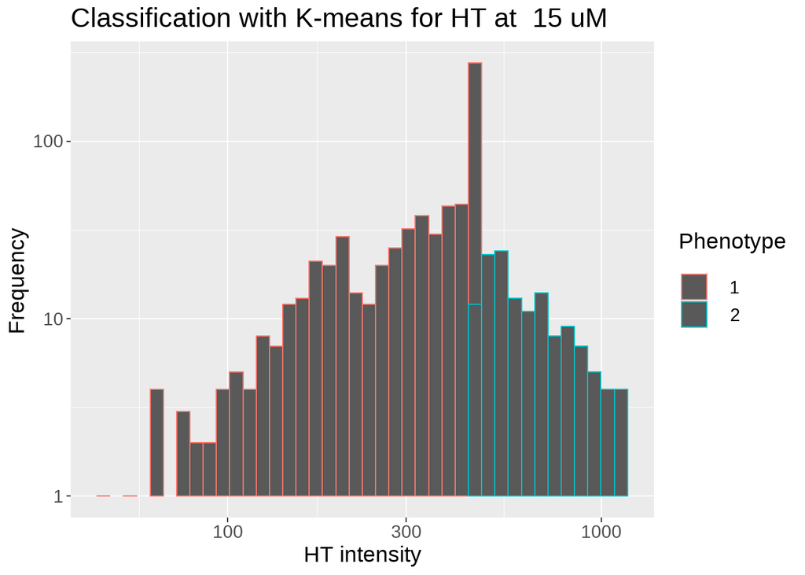

```r
# Join classification results to dataframe
df2$K_labels <- K_pred
df2$H_labels <- H_pred
# Create a vector of HT concentrations
htconc <- c(unique(df2$HT_Conc_uM))
for (i in seq_along(htconc)){
  data <- df2[df2$HT_Conc_uM == htconc[i],]
  p <- ggplot(data) +
          geom_histogram(aes(x= data$normed_intensity_ch2,
                        color = as.factor(data$K_labels)),
                        bins = 40,
                        show.legend = TRUE)+
          scale_y_log10(name = "Frequency")+
          scale_x_log10(name = "HT intensity")+
          scale_color_discrete(name = "Phenotype")+
          labs(title = paste("Classification with K-means for HT at ",htconc[i],"uM"))+
          theme(text=element_text(size=28))
  suppressWarnings(print(p))
}
```

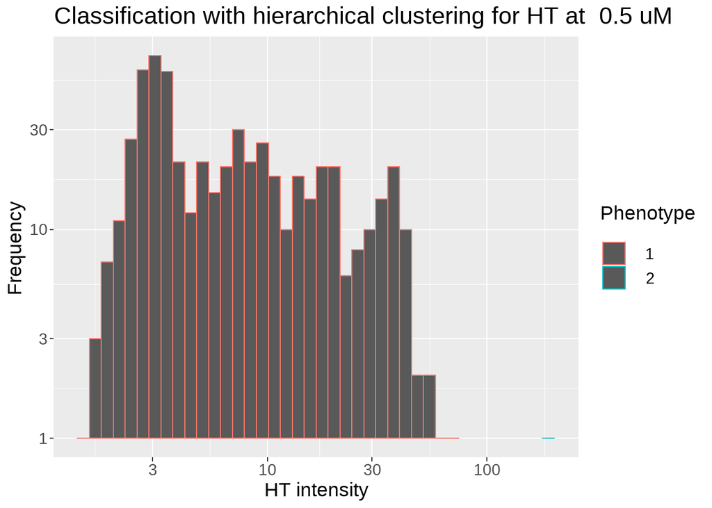

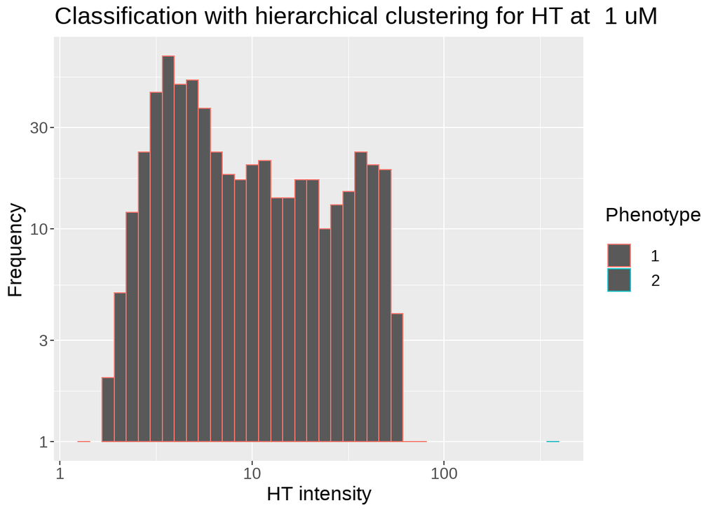

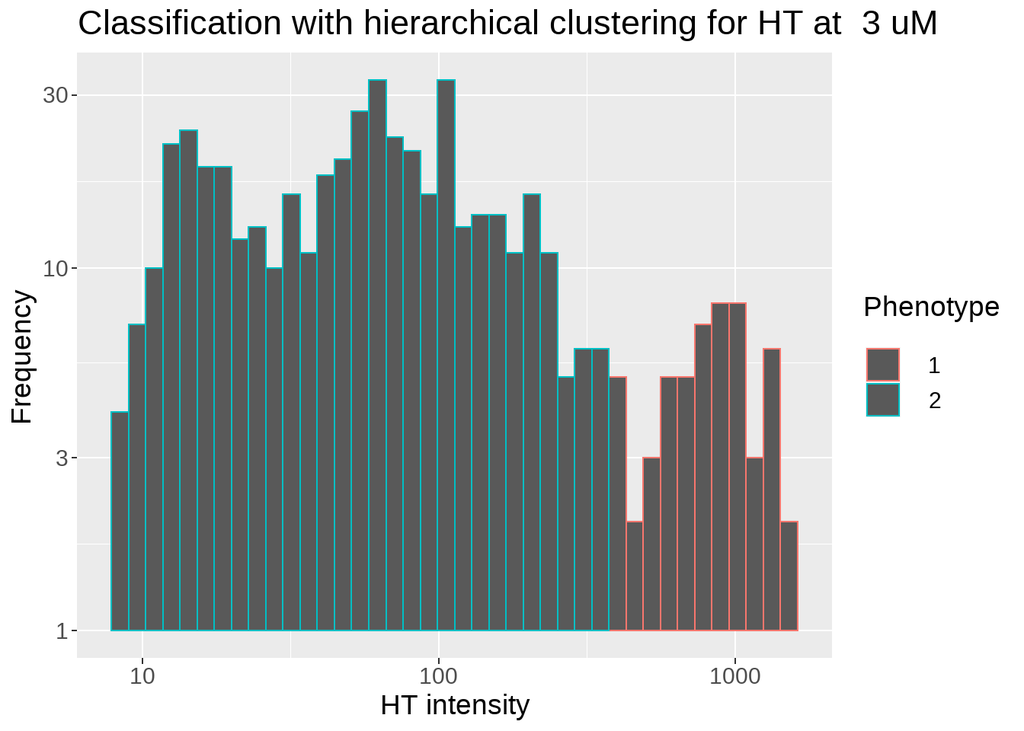

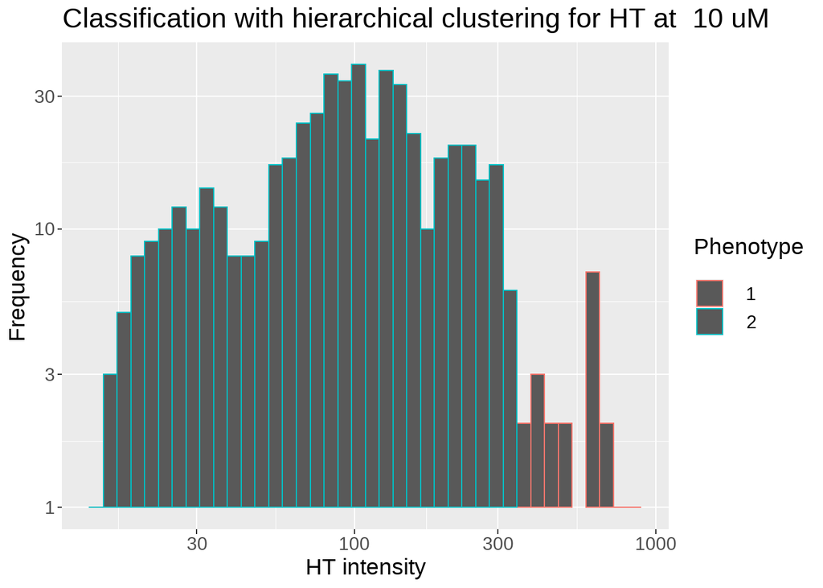

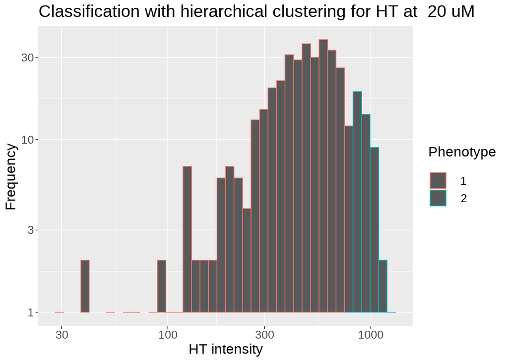

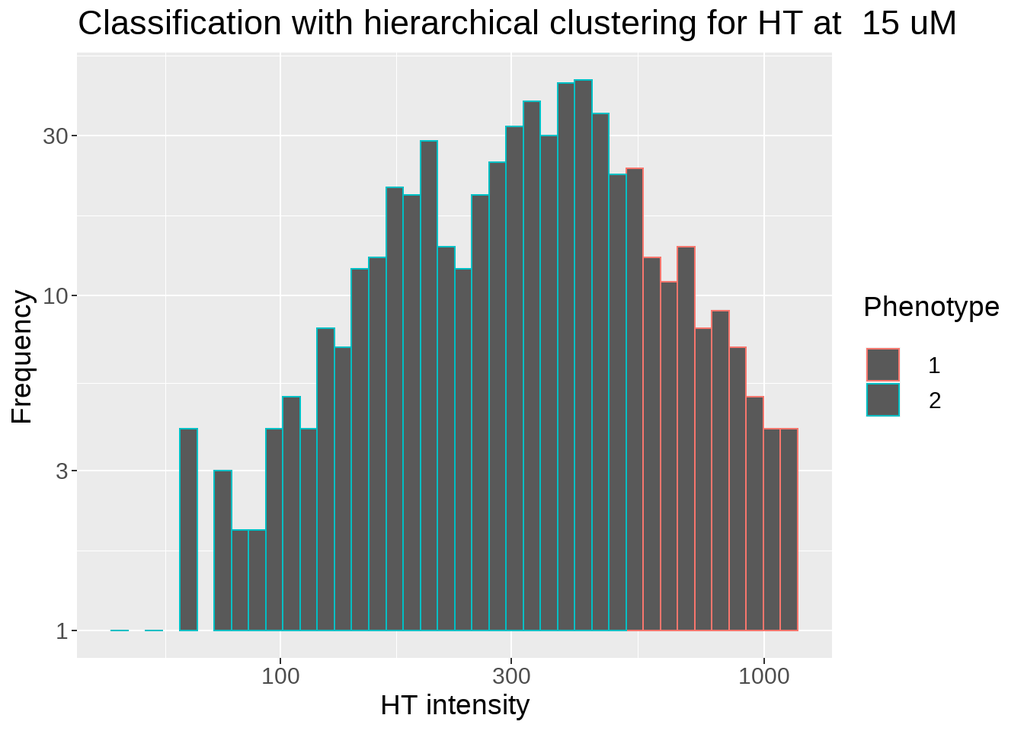

```r
for (i in seq_along(htconc)){
  data <- df2[df2$HT_Conc_uM == htconc[i],]
  q <- ggplot(data) +
          geom_histogram(aes(x= data$normed_intensity_ch2,
                                color = as.factor(data$H_labels)),
                                bins = 40,
                                show.legend = TRUE) +
          scale_y_log10(name = "Frequency")+
          scale_x_log10(name = "HT intensity")+
          scale_color_discrete(name = "Phenotype")+
          labs(title = paste("Classification with hierarchical clustering for HT at ",htconc[i],"uM"))+
          theme(text=element_text(size=28))
  suppressWarnings(print(q))
}
```

From the histograms, I can see that hierarchical clustering has better performance since there’s only 1 phenotype for each given bin. In the case of k-means clustering, there’s a mix of phenotypes in some particular bins. Also from the histograms, I can name cluster 1 as “dark” and cluster 2 as “bright” at concentration 0.5, 1, 20 uM, and cluster 1 as “bright”, cluster 2 as “dark” for concentrations 3, 10, 15 uM. Next, I will replace cluster indices with phenotype names

```r
# First, remove K_labels columns
df2 <- subset(df2,select= - K_labels)
# Replace 1 with "bright" and 2 with "dark" in H_labels columns at concentrations 3,10,15 uM
df2$H_labels[(df2$H_labels == 1) & (df2$HT_Conc_uM == 3 |
                                    df2$HT_Conc_uM == 10|
                                    df2$HT_Conc_uM == 15)] <- "bright"
df2$H_labels[df2$H_labels == 2 & (  df2$HT_Conc_uM == 3 |
                                    df2$HT_Conc_uM == 10|
                                    df2$HT_Conc_uM == 15)] <- "dark"
# Replace 1 with "dark" and 2 with "bright" in H_labels columns at concentrations 0.5,1,20 uM
df2$H_labels[(df2$H_labels == 2) & (df2$HT_Conc_uM == 0.5 |
                                    df2$HT_Conc_uM == 1   |
                                    df2$HT_Conc_uM == 20)] <- "bright"
df2$H_labels[df2$H_labels == 1 & (df2$HT_Conc_uM == 0.5 |
                                  df2$HT_Conc_uM == 1   |
                                  df2$HT_Conc_uM == 20)]   <- "dark"
# Change column name from H_labels to Classified_phenotype
colnames(df2)[7] <- "Classified_phenotype"
# Check data frame
df2
```

```
##       Time_m normed_intensity_ch2 HT_Conc_uM Genotype Phenotype Repeat
##    1:      0             30.27026        0.5       WT      dark      1
##    2:      0             38.10433        0.5       WT      dark      1
##    3:      0             38.81422        0.5       WT      dark      1
##    4:      0             46.90358        0.5       WT      dark      1
##    5:      0             41.01353        0.5       WT      dark      1
##   ---
## 3123:     90            129.51483       15.0       WT      dark      1
## 3124:     90            735.56150       15.0       WT      dark      1
## 3125:     90             75.55862       15.0       WT      dark      1
## 3126:     90            270.64246       15.0       WT      dark      1
## 3127:     90            122.30886       15.0       WT      dark      1
##       Classified_phenotype
##    1:                 dark
##    2:                 dark
##    3:                 dark
##    4:                 dark
##    5:                 dark
##   ---
## 3123:                 dark
## 3124:               bright
## 3125:                 dark
## 3126:                 dark
## 3127:                 dark
```

## Save dataframe in csv file

```r
write.csv(df2,"D:/Dropbox_dailescifi/Dropbox/RProject/ClusterHT.csv", row.names = FALSE)
```